# Project 1 - Final - ver 2

## Mercedes-Benz Greener Manufacturing

### Business Problem:

Since the first automobile, the Benz Patent Motor Car in 1886, Mercedes-Benz has stood for important automotive innovations. These include the passenger safety cell with a crumple zone, the airbag, and intelligent assistance systems. Mercedes-Benz applies for nearly 2000 patents per year, making the brand the European leader among premium carmakers. Mercedes-Benz is the leader in the premium car industry. With a huge selection of features and options, customers can choose the customized Mercedes-Benz of their dreams.

To ensure the safety and reliability of every unique car configuration before they hit the road, the company’s engineers have developed a robust testing system. As one of the world’s biggest manufacturers of premium cars, safety and efficiency are paramount on Mercedes-Benz’s production lines. However, optimizing the speed of their testing system for many possible feature combinations is complex and time-consuming without a powerful algorithmic approach.

You are required to **reduce the time that cars spend on the test bench**. Others will work with a dataset representing different permutations of features in a Mercedes-Benz car to predict the time it takes to pass testing. Optimal algorithms will contribute to faster testing, resulting in lower carbon dioxide emissions without reducing Mercedes-Benz’s standards.

### Data

#### Import libraries

```python
import pandas as pd
import numpy as np
import matplotlib.pyplot as plt
import seaborn as sns
from sklearn.preprocessing import LabelEncoder
from sklearn.preprocessing import StandardScaler
from sklearn.decomposition import PCA
import xgboost as xgb
%matplotlib inline
```

```python
# read in datasets
df_train = pd.read_csv('train.csv')
df_test = pd.read_csv('test.csv')

# dimensionality check
print(df_train.shape)
print(df_test.shape)
```

```
(4209, 378)
(4209, 377)
```

```python
df_train.head(10)
```

|  | ID | y | X0 | X1 | X2 | X3 | X4 | X5 | X6 | X8 | ... | X375 | X376 | X377 | X378 | X379 | X380 | X382 | X383 | X384 | X385 |
| --- | --- | --- | --- | --- | --- | --- | --- | --- | --- | --- | --- | --- | --- | --- | --- | --- | --- | --- | --- | --- | --- |
| 0 | 0 | 130.81 | k | v | at | a | d | u | j | o | ... | 0 | 0 | 1 | 0 | 0 | 0 | 0 | 0 | 0 | 0 |
| 1 | 6 | 88.53 | k | t | av | e | d | y | l | o | ... | 1 | 0 | 0 | 0 | 0 | 0 | 0 | 0 | 0 | 0 |
| 2 | 7 | 76.26 | az | w | n | c | d | x | j | x | ... | 0 | 0 | 0 | 0 | 0 | 0 | 1 | 0 | 0 | 0 |
| 3 | 9 | 80.62 | az | t | n | f | d | x | l | e | ... | 0 | 0 | 0 | 0 | 0 | 0 | 0 | 0 | 0 | 0 |
| 4 | 13 | 78.02 | az | v | n | f | d | h | d | n | ... | 0 | 0 | 0 | 0 | 0 | 0 | 0 | 0 | 0 | 0 |
| 5 | 18 | 92.93 | t | b | e | c | d | g | h | s | ... | 0 | 0 | 1 | 0 | 0 | 0 | 0 | 0 | 0 | 0 |
| 6 | 24 | 128.76 | al | r | e | f | d | f | h | s | ... | 0 | 0 | 0 | 0 | 0 | 0 | 0 | 0 | 0 | 0 |
| 7 | 25 | 91.91 | o | l | as | f | d | f | j | a | ... | 0 | 0 | 0 | 0 | 0 | 0 | 0 | 0 | 0 | 0 |
| 8 | 27 | 108.67 | w | s | as | e | d | f | i | h | ... | 1 | 0 | 0 | 0 | 0 | 0 | 0 | 0 | 0 | 0 |
| 9 | 30 | 126.99 | j | b | aq | c | d | f | a | e | ... | 0 | 0 | 1 | 0 | 0 | 0 | 0 | 0 | 0 | 0 |

10 rows × 378 columns

```python
df_train.describe()
```

|  | ID | y | X10 | X11 | X12 | X13 | X14 | X15 | X16 | X17 | ... | X375 | X376 | X377 | X378 | X379 | X380 | X382 | X383 | X384 | X385 |
| --- | --- | --- | --- | --- | --- | --- | --- | --- | --- | --- | --- | --- | --- | --- | --- | --- | --- | --- | --- | --- | --- |
| count | 4209.000000 | 4209.000000 | 4209.000000 | 4209.0 | 4209.000000 | 4209.000000 | 4209.000000 | 4209.000000 | 4209.000000 | 4209.000000 | ... | 4209.000000 | 4209.000000 | 4209.000000 | 4209.000000 | 4209.000000 | 4209.000000 | 4209.000000 | 4209.000000 | 4209.000000 | 4209.000000 |
| mean | 4205.960798 | 100.669318 | 0.013305 | 0.0 | 0.075077 | 0.057971 | 0.428130 | 0.000475 | 0.002613 | 0.007603 | ... | 0.318841 | 0.057258 | 0.314802 | 0.020670 | 0.009503 | 0.008078 | 0.007603 | 0.001663 | 0.000475 | 0.001426 |
| std | 2437.608688 | 12.679381 | 0.114590 | 0.0 | 0.263547 | 0.233716 | 0.494867 | 0.021796 | 0.051061 | 0.086872 | ... | 0.466082 | 0.232363 | 0.464492 | 0.142294 | 0.097033 | 0.089524 | 0.086872 | 0.040752 | 0.021796 | 0.037734 |
| min | 0.000000 | 72.110000 | 0.000000 | 0.0 | 0.000000 | 0.000000 | 0.000000 | 0.000000 | 0.000000 | 0.000000 | ... | 0.000000 | 0.000000 | 0.000000 | 0.000000 | 0.000000 | 0.000000 | 0.000000 | 0.000000 | 0.000000 | 0.000000 |
| 25% | 2095.000000 | 90.820000 | 0.000000 | 0.0 | 0.000000 | 0.000000 | 0.000000 | 0.000000 | 0.000000 | 0.000000 | ... | 0.000000 | 0.000000 | 0.000000 | 0.000000 | 0.000000 | 0.000000 | 0.000000 | 0.000000 | 0.000000 | 0.000000 |
| 50% | 4220.000000 | 99.150000 | 0.000000 | 0.0 | 0.000000 | 0.000000 | 0.000000 | 0.000000 | 0.000000 | 0.000000 | ... | 0.000000 | 0.000000 | 0.000000 | 0.000000 | 0.000000 | 0.000000 | 0.000000 | 0.000000 | 0.000000 | 0.000000 |
| 75% | 6314.000000 | 109.010000 | 0.000000 | 0.0 | 0.000000 | 0.000000 | 1.000000 | 0.000000 | 0.000000 | 0.000000 | ... | 1.000000 | 0.000000 | 1.000000 | 0.000000 | 0.000000 | 0.000000 | 0.000000 | 0.000000 | 0.000000 | 0.000000 |
| max | 8417.000000 | 265.320000 | 1.000000 | 0.0 | 1.000000 | 1.000000 | 1.000000 | 1.000000 | 1.000000 | 1.000000 | ... | 1.000000 | 1.000000 | 1.000000 | 1.000000 | 1.000000 | 1.000000 | 1.000000 | 1.000000 | 1.000000 | 1.000000 |

8 rows × 370 columns

The reduction in the number of columns from 378 to 370 indicates the 8 categorical columns in the dataset. From the count values, there appears to be no missing value. Using a function to confirm:

#### Q1. Check for null and unique values for test and train sets.

```python
# check for null and missing values in both the train and test data

def check_missing_values(df):
    if df.isnull().any().any():
        print('There are missing values in the dataframe')
    else:
        print('There are no missing values in the dataframe')

check_missing_values(df_train)
check_missing_values(df_test)
```

```
There are no missing values in the dataframe
There are no missing values in the dataframe
```

```python
# check the data types in the dataset
type_df = df_train.dtypes.reset_index()
type_df.columns = ['count', 'dtypes']
type_df.groupby('dtypes').agg('count').reset_index()
```

|  | dtypes | count |
| --- | --- | --- |
| 0 | int64 | 369 |
| 1 | float64 | 1 |
| 2 | object | 8 |

There are 369 features with dtypes int 64, 8 are most probably categorical features and 1 float which is the target variable.

```python
# check for unique values for categorical data in train and test data sets
print('Unique values for train data:')
data = df_train[['X0', 'X1', 'X2', 'X3', 'X4', 'X5', 'X6', 'X8']]
for col in data.columns:
    print(col, ':', len(data[col].unique()), 'labels')

print('Unique values for test data:')
data2 = df_test[['X0', 'X1', 'X2', 'X3', 'X4', 'X5', 'X6', 'X8']]
for col in data2.columns:
    print(col, ':', len(data2[col].unique()), 'labels')
```

```
Unique values for train data:
X0 : 47 labels
X1 : 27 labels
X2 : 44 labels
X3 : 7 labels
X4 : 4 labels
X5 : 29 labels
X6 : 12 labels
X8 : 25 labels
Unique values for test data:
X0 : 49 labels
X1 : 27 labels
X2 : 45 labels
X3 : 7 labels
X4 : 4 labels
X5 : 32 labels
X6 : 12 labels
X8 : 25 labels
```

We see that X4 has the least number of unique values followed by X3.

Exploring further to understand the target and independent variables.

```python
unique_values_dict = {}
for col in df_train.columns:
    if col not in ["ID", "y", "X0", "X1", "X2", "X3", "X4", "X5", "X6", "X8"]:
        unique_value = str(np.sort(df_train[col].unique()).tolist())
        tlist = unique_values_dict.get(unique_value, [])
        tlist.append(col)
        unique_values_dict[unique_value] = tlist[:]
for unique_val, columns in unique_values_dict.items():
    print("Columns containing the unique values : ",unique_val)
    print(columns)
    print("--------------------------------------------------")
```

```
Columns containing the unique values :  [0, 1]
['X10', 'X12', 'X13', 'X14', 'X15', 'X16', 'X17', 'X18', 'X19', 'X20', 'X21', 'X22', 'X23', 'X24', 'X26', 'X27', 'X28', 'X29', 'X30', 'X31', 'X32', 'X33', 'X34', 'X35', 'X36', 'X37', 'X38', 'X39', 'X40', 'X41', 'X42', 'X43', 'X44', 'X45', 'X46', 'X47', 'X48', 'X49', 'X50', 'X51', 'X52', 'X53', 'X54'…
--------------------------------------------------
Columns containing the unique values :  [0]
['X11', 'X93', 'X107', 'X233', 'X235', 'X268', 'X289', 'X290', 'X293', 'X297', 'X330', 'X347']
--------------------------------------------------
```

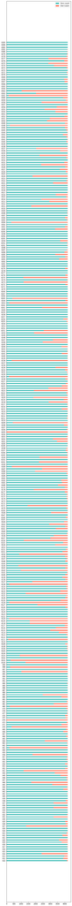

```python
# Understanding the binary features
zero_count_list = []
one_count_list = []
cols_list = unique_values_dict['[0, 1]']
for col in cols_list:
    zero_count_list.append((df_train[col]==0).sum())
    one_count_list.append((df_train[col]==1).sum())

N = len(cols_list)
ind = np.arange(N)
width = 0.35

plt.figure(figsize=(7,100))
p1 = plt.barh(ind, zero_count_list, width, color='lightseagreen')
p2 = plt.barh(ind, one_count_list, width, left=zero_count_list, color="tomato")
plt.yticks(ind, cols_list)
plt.legend((p1[0], p2[0]), ('Zero count', 'One Count'))
plt.show()
```

From the plot above, many features have very low variance while some have constant values

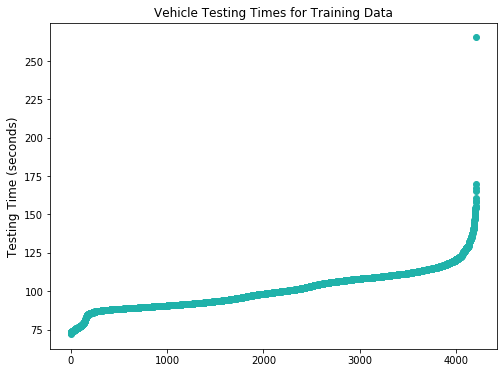

```python
# understanding the target variable 'testing time (sec)'

plt.figure(figsize=(8,6))
plt.scatter(range(df_train.shape[0]), np.sort(df_train.y.values), color='lightseagreen')
plt.title('Vehicle Testing Times for Training Data')
plt.xlabel('', fontsize=12)
plt.ylabel('Testing Time (seconds)', fontsize=12)
plt.show()
```

There is an obvious outlier with Testing time above 250 seconds as shown in plot above.

```python
df_train[df_train['y'] > 250]
```

|  | ID | y | X0 | X1 | X2 | X3 | X4 | X5 | X6 | X8 | ... | X375 | X376 | X377 | X378 | X379 | X380 | X382 | X383 | X384 | X385 |
| --- | --- | --- | --- | --- | --- | --- | --- | --- | --- | --- | --- | --- | --- | --- | --- | --- | --- | --- | --- | --- | --- |
| 883 | 1770 | 265.32 | y | r | ai | f | d | ag | l | t | ... | 0 | 0 | 0 | 0 | 0 | 0 | 0 | 0 | 0 | 0 |

1 rows × 378 columns

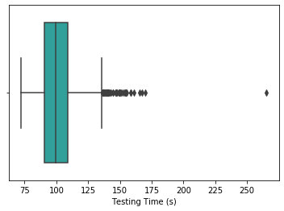

```python
# visualizing the target variable again with a boxplot
sns.boxplot(x=df_train['y'], color='lightseagreen')
plt.xlabel('Testing Time (s)')
```

The detected outlier will be removed from the target variable.

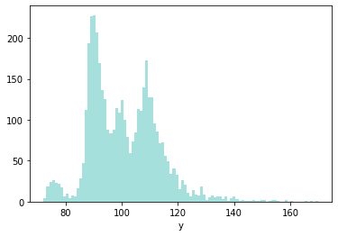

```python
# remove the outlier
filter = df_train['y'] < 250
df_train = df_train[filter]
sns.distplot(df_train['y'][df_train['y']<250],bins=100,kde=False, color='lightseagreen')
```

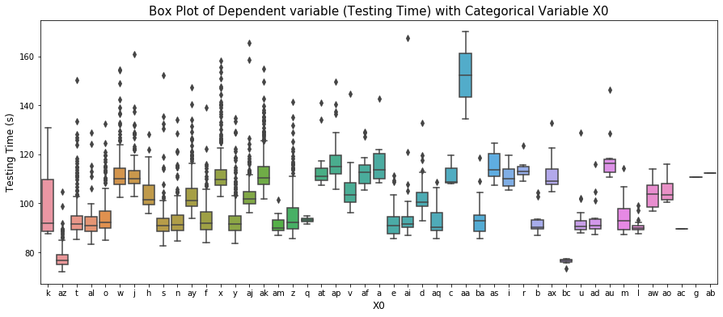

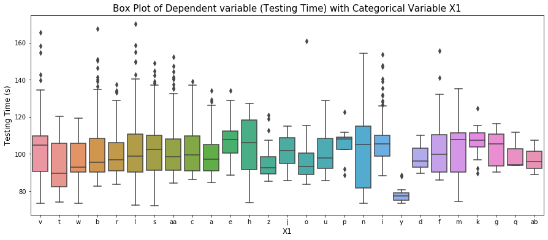

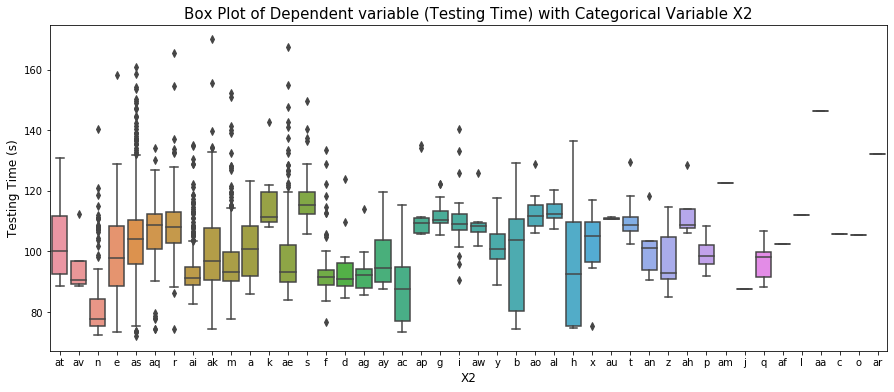

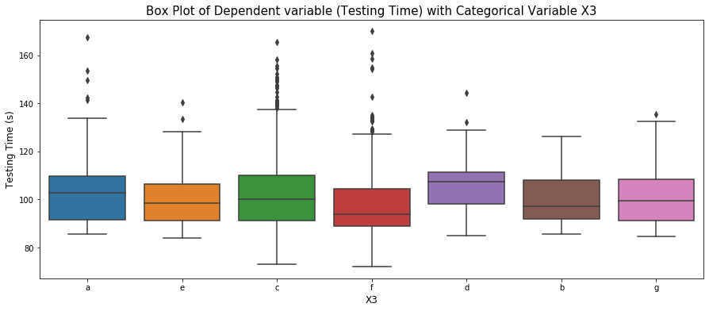

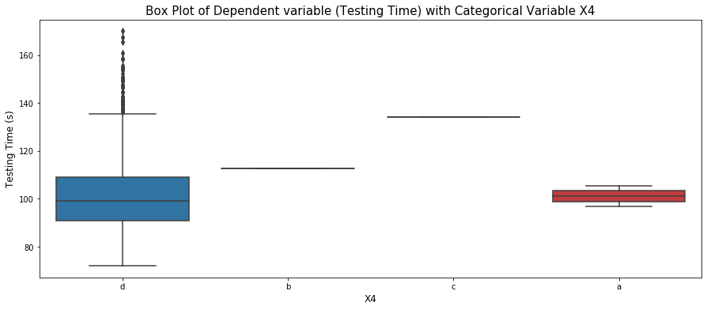

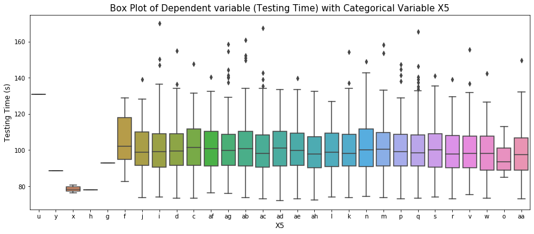

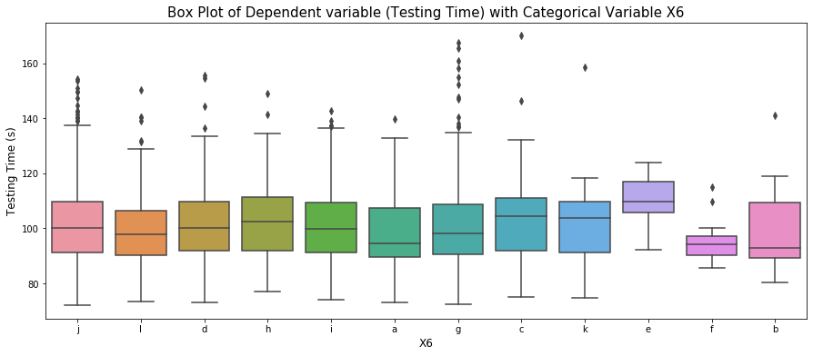

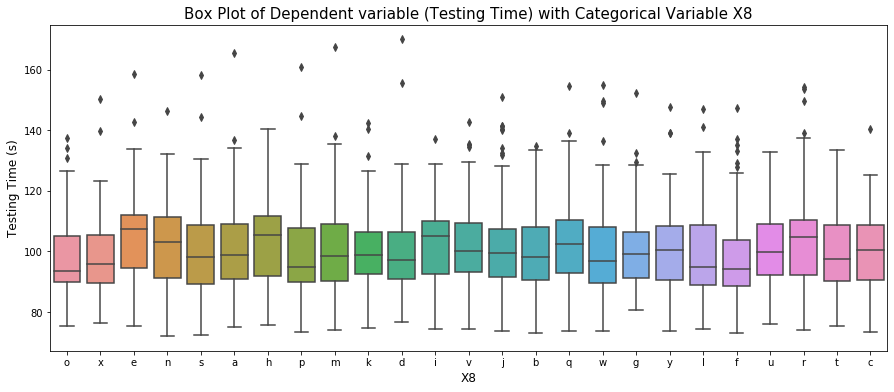

```python
# understanding the categorical features

# using a for loop to plot the categorical features
column_names = ['X0', 'X1', 'X2', 'X3', 'X4', 'X5', 'X6', 'X8']
for column in column_names:
    plt.figure(figsize=(15,6))
    sns.boxplot(x=column, y='y', data=df_train )
    plt.title("Box Plot of Dependent variable (Testing Time) with Categorical Variable " + column, fontsize=15)
    plt.xlabel(column, fontsize=12)
    plt.ylabel('Testing Time (s)', fontsize=12)
    plt.show()
```

The 'X4' feature has very low variance compared to other categorical features so it will be removed from the dataset.

```python
# Check for duplicate features

rem_cols = []
dups = list(df_train.T.index[df_train.T.duplicated(keep="first")].values)
print(dups)
rem_cols.extend(dups)
```

```
['X35', 'X37', 'X39', 'X76', 'X84', 'X93', 'X94', 'X102', 'X107', 'X113', 'X119', 'X122', 'X134', 'X146', 'X147', 'X172', 'X199', 'X213', 'X214', 'X216', 'X222', 'X226', 'X227', 'X232', 'X233', 'X235', 'X239', 'X242', 'X243', 'X244', 'X245', 'X247', 'X248', 'X253', 'X254', 'X262', 'X266', 'X268', 'X…
```

```python
df_num = df_train.loc[:,df_train.dtypes==np.int64]
```

#### Q2. If for any column(s), the variance is equal to zero, then you need to remove those variable(s).

```python
# identifying features with 0 variance
temp = []
for i in df_num.columns:
    if df_train[i].var()==0:
        temp.append(i)

print(len(temp))
print(temp)
```

```
12
['X11', 'X93', 'X107', 'X233', 'X235', 'X268', 'X289', 'X290', 'X293', 'X297', 'X330', 'X347']
```

```python
# dropping low variance and irrelevant columns

rem_cols.extend(temp)
rem_cols = list(set(rem_cols))
rem_cols.append('X4')
rem_cols.append('ID')
print(df_train.shape)
df_train_modified = df_train.drop(rem_cols, axis=1)
print(df_train_modified.shape)
```

```
(4208, 378)
(4208, 319)
```

```python
# confirming how many features were removed
print("Number of removed features: ",df_train.shape[1] - df_train_modified.shape[1])
```

```
Number of removed features:  59
```

```python
# splitting train data into X & y
X_train = df_train_modified.drop('y', axis=1)
y = df_train_modified['y']

print(X_train.shape)
print(y.shape)
```

```
(4208, 318)
(4208,)
```

#### Q3. Apply label encoder.

Project instruction requested for Label encoder, instead of One-hot encoder.

```python
# initialize
label_encoder = LabelEncoder()

# encode the categorical features 'X0', 'X1', 'X2', 'X3', 'X5', 'X6', 'X8'
X_train['X0'] = label_encoder.fit_transform(X_train['X0'])
X_train['X1'] = label_encoder.fit_transform(X_train['X1'])
X_train['X2'] = label_encoder.fit_transform(X_train['X2'])
X_train['X3'] = label_encoder.fit_transform(X_train['X3'])
X_train['X5'] = label_encoder.fit_transform(X_train['X5'])
X_train['X6'] = label_encoder.fit_transform(X_train['X6'])
X_train['X8'] = label_encoder.fit_transform(X_train['X8'])
```

```python
# check the data to confirm the values were converted
X_train.head()
```

|  | X0 | X1 | X2 | X3 | X5 | X6 | X8 | X10 | X12 | X13 | ... | X373 | X374 | X375 | X376 | X377 | X378 | X379 | X380 | X383 | X384 |
| --- | --- | --- | --- | --- | --- | --- | --- | --- | --- | --- | --- | --- | --- | --- | --- | --- | --- | --- | --- | --- | --- |
| 0 | 32 | 23 | 17 | 0 | 24 | 9 | 14 | 0 | 0 | 1 | ... | 0 | 0 | 0 | 0 | 1 | 0 | 0 | 0 | 0 | 0 |
| 1 | 32 | 21 | 19 | 4 | 28 | 11 | 14 | 0 | 0 | 0 | ... | 0 | 0 | 1 | 0 | 0 | 0 | 0 | 0 | 0 | 0 |
| 2 | 20 | 24 | 34 | 2 | 27 | 9 | 23 | 0 | 0 | 0 | ... | 0 | 0 | 0 | 0 | 0 | 0 | 0 | 0 | 0 | 0 |
| 3 | 20 | 21 | 34 | 5 | 27 | 11 | 4 | 0 | 0 | 0 | ... | 0 | 0 | 0 | 0 | 0 | 0 | 0 | 0 | 0 | 0 |
| 4 | 20 | 23 | 34 | 5 | 12 | 3 | 13 | 0 | 0 | 0 | ... | 0 | 0 | 0 | 0 | 0 | 0 | 0 | 0 | 0 | 0 |

5 rows × 318 columns

```python
# assign y data to y_train variable
y_train = y
```

#### Remove Correlated Features

```python
# find and remove correlated features
def correlation(dataset, threshold):
    col_corr = set() # Set of all the names of correlated columns
    corr_matrix = dataset.corr()
    for i in range(len(corr_matrix.columns)):
        for j in range(i):
            if abs(corr_matrix.iloc[i, j]) > threshold: # we are interested in absolute coeff value
                colname = corr_matrix.columns[i]    # getting the name of column
                col_corr.add(colname)
    return col_corr   # return correlated columns
```

```python
threshold = 0.8
correlated_columns = correlation(X_train,threshold)
```

```python
X_train = X_train.drop(correlated_columns, axis=1)
```

#### Processing Test data

```python
# Check for duplicate features

rem_cols = []
dups2 = list(df_test.T.index[df_test.T.duplicated(keep="first")].values)
print(dups2)
rem_cols.extend(dups)

df_num = df_test.loc[:,df_test.dtypes==np.int64]

# removing features with 0 variance
temp = ['X11', 'X93', 'X107', 'X233', 'X235', 'X268', 'X289', 'X290', 'X293', 'X297', 'X330', 'X347']

rem_cols.extend(temp)
rem_cols = list(set(rem_cols))
rem_cols.append('X4')
rem_cols.append('ID')
print(df_test.shape)
df_test_modified = df_test.drop(rem_cols, axis=1)
print(df_test_modified.shape)

print("Number of removed features: ",df_test.shape[1] - df_test_modified.shape[1])

X_test = df_test_modified

from sklearn.preprocessing import LabelEncoder

label_encoder = LabelEncoder()

# encode the categorical features 'X0', 'X1', 'X2', 'X3', 'X5', 'X6', 'X8'
X_test['X0'] = label_encoder.fit_transform(X_test['X0'])
X_test['X1'] = label_encoder.fit_transform(X_test['X1'])
X_test['X2'] = label_encoder.fit_transform(X_test['X2'])
X_test['X3'] = label_encoder.fit_transform(X_test['X3'])
X_test['X5'] = label_encoder.fit_transform(X_test['X5'])
X_test['X6'] = label_encoder.fit_transform(X_test['X6'])
X_test['X8'] = label_encoder.fit_transform(X_test['X8'])


X_test = X_test.drop(correlated_columns, axis=1)
```

```
['X35', 'X37', 'X39', 'X76', 'X84', 'X102', 'X113', 'X119', 'X134', 'X140', 'X146', 'X147', 'X172', 'X199', 'X213', 'X214', 'X216', 'X222', 'X226', 'X227', 'X239', 'X243', 'X244', 'X253', 'X254', 'X258', 'X260', 'X262', 'X263', 'X279', 'X293', 'X295', 'X296', 'X299', 'X302', 'X324', 'X326', 'X330', …
(4209, 377)
(4209, 318)
Number of removed features:  59
```

**Assumption for this project, y_test was not provided to simulate real-life competitions.

#### Q4. Perform dimensionality reduction.

```python
# Normalize the data
sc = StandardScaler()

X_train = sc.fit_transform(X_train)
X_test = sc.fit_transform(X_test)

print(X_train.shape)
print(X_test.shape)
```

```
(4208, 235)
(4209, 235)
```

```python
# using PCA for dimensionality reduction
pca = PCA(n_components=2)

X_train_pca = pca.fit_transform(X_train)
X_test_pca = pca.fit_transform(X_test)

print('The variance values of the PC components are:')
print(pca.explained_variance_ratio_)
```

```
The variance values of the PC components are:
[0.04215126 0.03887038]
```

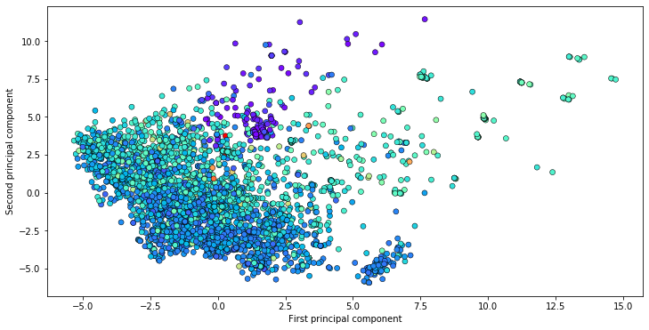

```python
# visualize the principal components
plt.figure(figsize=(12,6))

plt.scatter(X_train_pca[:,0], X_train_pca[:,1], c=y_train, cmap='rainbow', linewidth=0.5, edgecolor='black')
plt.xlabel('First principal component')
plt.ylabel('Second principal component')
```

The first two principal components describe approximately 8% of the variance in the data. In order gain a more comprehensive view of how each principal component explains the variance within the data, we will construct a scree plot.

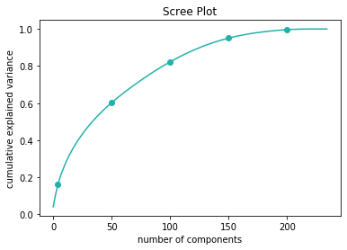

```python
# deciding the number of principal components to use
pca = PCA()
X_train_pca = pca.fit_transform(X_train)
markers_on = [4, 50, 100, 150, 200]
plt.plot(np.cumsum(pca.explained_variance_ratio_), linestyle='-', markevery=markers_on, marker='o', color='lightseagreen')
plt.title('Scree Plot')
plt.xlabel('number of components')
plt.ylabel('cumulative explained variance')
plt.show()
```

Our scree plot shows that the first 150 principal components describe most of the variation (information) within the data. This is a reduction from the initial 235 features. Therefore, the first 150 eigenvectors will be used to construct the dimensions for the new feature space.

```python
pca = PCA(n_components=150)
X_train_pca = pca.fit_transform(X_train)
X_test_pca = pca.fit_transform(X_test)
```

```python
print(X_train_pca.shape)
print(X_test_pca.shape)
```

```
(4208, 150)
(4209, 150)
```

```python
# building the model with XGBoost
# convert data to DMatrix
D_train = xgb.DMatrix(X_train_pca, label=y_train)
D_test = xgb.DMatrix(X_test_pca)
```

```python
# initialize parameters
param = {'eta':0.01, 'max_depth':4, 'objective':'reg:squarederror'}

xgb_model = xgb.train(param, D_train, 200)
```

#### Q5. Predict your test_df values using XGBoost.

```python
# predict the test time
y_xgb_pred = xgb_model.predict(D_test)
```

```python
print('Predicted Testing Time:')
print(y_xgb_pred)
```

```
Predicted Testing Time:
[83.80621  87.093414 82.62807  ... 83.739174 93.58947  86.38244 ]
```

Presenting the first 5 testing time predictions as a dataframe.

```python
sub = pd.DataFrame(index=df_test['ID'].values)
sub['y_predicted (sec)'] = y_xgb_pred
sub.head()
```

|  | y_predicted (sec) |
| --- | --- |
| 1 | 83.806213 |
| 2 | 87.093414 |
| 3 | 82.628067 |
| 4 | 84.847832 |
| 5 | 95.574280 |